# A bayesian approach to identify mortgage default at city level

Yi Chen, Andres Potapczynski, Jongwoo Choi

December 2018

## Abstract

# Introduction

## Background

**In this project we are helping a small mortgage lending start-up in country understand how different cities differ in their risk to default on their mortgage.** This start-up has recently entered the market and wants us to help it asses how it should expand geographically throughout the country. Put differently, they want us to help them prioritize the expansion to cities that have shown the highest compliance as well as to understand how different variables predict such compliance.

## Research Questions

Succintly, our research question is the following:

- What covariates influence / help predict the default rate at each city in Mexico?

The context of why our research question is relevant is the following. We are helping a small mortgage lending start-up in Mexico understand how different cities differ in their risk to default on their mortgage. This start-up has recently entered the market and wants us to help it asses how it should expand geographically throughout the country. Put differently, they want us to help them prioritize the expansion to cities that have shown the highest compliance as well as to understand how different variables predict such compliance.

It is also worth mentioning that someone defaulting generates an impact directly to the company’s bottomline and, therefore, understanding why this happends (what variables influence this) and an acurate prediction of the number of defaults could potentially allow the company to flourish. Put differently, inacurate predictions threaten the survival of this start-up. Since the company is more concern about predicting the number of defaults than understanding why some individual might default, our models then focused on predicting the total number of defaults per city with city specific covariates (which are simply the average values of the covariates for the individuals residing in that city). As it will be shown below, this perspective reduced the noise for the individual level data and allowed us to succesfully give an answer.

## Hypothesis

In order to accomplish our objective, we were provided with a large data set of 30,499 mortgages with over 90 covariates (for a comprehensive explanation of the data set see the next section). This data set was provided by another player in the market which might acquire the start-up. We wanted to get some domain knowledge so we interviewed the startup to understand their main hypothesis of why different cities might have a diverging default behavior as well as to retrieve all the domain knowledge possible for both our modeling and our prior assumptions. Summarizing their points:

1. Some northern states in country are fighting a drug war against different cartels and some cities have been specially damaged. Thus, even though the northern region of country is one of the wealthiest, cities belonging to the some states might present higher default rates that cannot be explained with the covariates that we were given (since non are related to this event).
2. Poor southern states have a cultural tendency to fall easier into default. Some states might present a higher default rate even among high income individuals. The rational is that, given the low financial penetration in those states, individuals are less concern about their credit score and thus are more prone to abandon their properties if they fall into financial distress or even when they dislike their property.
3. The covariates related to employment should be the most predictive variables. The start-up believes that the main driver of default is that people lose their jobs. Thus, the employment variables of our data set should be the most relevant.

# Data

## Dataset & Descriptive Statisics

### Introduction

[…] In this section we examine three main elements of the data set that we were given. First, we expose the set of covariates that we were given. Next, we show the most important plots from of exploratory data analysis. Finally, we detail the preprocessing steps that we took before pushing the data into STAN.

**we were provided with a large data set of 30,499 mortgages with over 90 covariates**

### Covariates

The average default rate is 6%. Also, the data set provided was their latest report available at August 2018. We group the covariates in the following categories:

1. [Geographics] state, city and zip: These features will allow me to understand if the client’s behavior varies by geography. Also, I have this location features for both the house acquired and for the owner’s location.
2. [Demographics] age, sex, ratio, risk_index, client_income and credit_score. The feature ratio is the % of the client’s income that the monthly payments for its mortgage represent. The risk_index is a variable that combines several metrics associated with his likelihood of paying a debt. The client_income feature is the monthly income that the person earned at that moment in time when she signed the mortgage. Finally, the ordinal variable credit_score evaluates how the client has performed in previous debts (related to risk_index).
3. [Economics]
- [Asset features] vendor name, new_used, and appraisal_value: These features tell us who was the vendor (either a construction company or an individual) and if the asset is new or not as well as the amount of money the person was given as a mortgage.
- [Employment] employer_name and factor_employed. The first feature conveys who is the employer and the second one information about the client’s status of employment.
- [Payment Records] days_pay, and y. The first feature counts the number of days that have passed between the last payment date and the date on which the mortgage started. The next feature is the target variable that is 1 if the mortgage has at least one month without a payment and 0 otherwise.

## Data Processing

Below we list the main preprocessing steps that we did with the data

1. **Aggregated the variables at the city level.** The data set that we were given was at the individual mortgage level. In order to make it suitable for the geographical analysis we aggregated the relevant variables at the city level. The majority by the mean but some by their sum. For example, individual income and age were transformed into mean income and mean age in that city were as the binary response when people default was summed into the number of people that defaulted in that city.
2. **Transform to log space the variables related to money.** As it is well-known, income distributions tend to be skewed and to resemble extreme value densities. Thus, we transformed those values into the log space to bring closer together the large values that were present.
3. **Z-score all the variables.** Finally we, z-scored all the variables to put them in the same scale and thus assuring that placing a similar prior in their slope coefficients (βj) made sense.

# Modeling

## Introduction

### Model Specification & Logic Flow

### Parameter Specification

### Prior Selection Principle

## Baseline Model : Linear Binormial Regression

### Model Introduction

We process by treating the underlying deterministic model as providing an expected default times for each city around which there will be variation due to both measurement error and simplifications. Consider the typical formulation of a linear regression, where $y_n$ is the is an observable default time, $x_n$ is a row vector of unmodeled predictors ( independent variables), $\beta$ is a coefficient vector parameter and we separate the intercep as $a$. In the city level, we assume that the number of individual records in city $i$ is $n_i$.Thus, we have the model:

$$y_i \sim Binormial(n_{i},logit^{-1}(a + x_i\beta))$$
As a robust prior distribution option, we take $\beta \sim cauchy(location=0,scale=2.5)$.

## Model Extension: CAR & Zero Inflation

### Model Introduction

In model 2, we will extend this model in two ways: (1) incoperate the geographic state information (2) zero inflated model.

1. Extension one: Incoperate Geographic Information

In this project, we utilize the IAR prior for state feature. Intrisnic conditional autoregressive (IAR) is an extension of conditional autoregressive (CAR) models, which are popular as prior distributions for spatial random effects with areal spatial data. In our model, we have a random quantity $\phi = (\phi_1,\phi_2,...,\phi_{32})$ at 32 state areal locations. In each state, we have the individual records aggregated at the city level. And each city data belong to one state. According to the Brook’s Lemma, the joint the distribution of $\phi$ can be expressed as the followings:
$$\phi \sim N(0,[D_{\tau} (I-\alpha B)]^{-1})$$
In this formula, we have:

- $D = diag(m_i)$ is an $32 \times 32$ diagonal matrix with $m_i$ is the number of the neighbors for the state i
- $D_{\tau} = \tau D$ and $\tau$ is the hyperparameter in the conditional distributions of the $\phi$
- $\alpha$ is the parameter that controls spatial dependence. In IAR, we let $\alpha =1$
- $B = D^{-1} W$ is the scaled adjacency matrix. And $W$ is the adjacency matrix. ($w_{ii}=0$,$w_{ij}=1$ if the state i is a neighbor of state j , and $w_{ij}=1$ otherwise)

We can simplifies the IAR model to:

$$\phi \sim N(0,\tau (D-W)]^{-1})$$
In IAR model, we have a singular precision matrix and an improper prior distribution. However, in practice, IAR models are fit with a sum to zero constrains: $\sum_{i}\phi_i = 0$ for each connected component of the graph. In this way, we can interpret both overall means and the component-wise means.

Through log probability accumulator, we can accure computational efficiency gains. We have:

$$log(p(\phi | \tau)) = -\frac{n}{2}log(2\pi) + \frac{1}{2}log(det^{*}(\tau(D-W))) - \frac{1}{2}\phi^{T}\tau(D-W)\phi$$
$$=-\frac{n}{2}log(2\pi) + \frac{1}{2}log(\tau^{n-k}) + \frac{1}{2}log(det^{*}(\tau(D-W)) - \frac{1}{2}\phi^{T}\tau(D-W)\phi$$

In this formula, $det^{*}(A)$ is the generlized determinant of the square matrix A defined as the product of its non-zero eigenvalues, and the k is the number of the connented component in the graph.(k=1 for our data) Dropping the additive constants, the qunantity to increment becomes:

$$\frac{1}{2}log(\tau^{n-k}) - \frac{1}{2}\phi^{T}\tau(D-W)\phi$$

In our model, we assume the hyperparameter $\tau \sim Gamma(shape = 2,rate = 2)$. We define the sparse_iar_lpdf function as a more efficient spare representation as the following:

```r
functions {
  real sparse_iar_lpdf(vector phi, real tau, int[,] W_sparse,
            vector D_sparse, vector lambda, int S, int W_n) {
      row_vector[S] phit_D; // phi' * D
      row_vector[S] phit_W; // phi' * W
      vector[S] ldet_terms;

      phit_D = (phi .* D_sparse)';
      phit_W = rep_row_vector(0, S);
      for (i in 1:W_n) {
        phit_W[W_sparse[i, 1]] = phit_W[W_sparse[i, 1]] +
                                 phi[W_sparse[i, 2]];
        phit_W[W_sparse[i, 2]] = phit_W[W_sparse[i, 2]] +
                                 phi[W_sparse[i, 1]];
      }

      return 0.5 * ((S-1) * log(tau)
            - tau * (phit_D * phi - (phit_W * phi)));
  }
}
```

After we get the IAR prior, we can take it into our model.For the $i$ the city in the $j$ the state, we have:

$$y_{ij} \sim Binormial(n_{ij},logit^{-1}(a + \phi_j + x_{ij}\beta))$$

Here are the Reason for design the model in this way rather than hierarchical model:

- Hierarchical extension will greatly expend the demension of the parameter space. Consequently, the estimation convergence would be much more difficult.Just focus on the binormial regression part. If we take the hierarchical extension both on the intercept and coefficient terms, there will have $32 \times 1 = 32$ intercept paramters and $32 \times 7 = 224$ coefficient parameters (total 256 parameters).For taking the hierarchical extension on $\beta$s, we have 1 intercept and $7 \times 32 = 224$ coefficient in the binormial regression model (total 225 parameters). But now, we only have 1 parameter for overall intercept, 32 parameter for the state level effecr and 7 parameter for the different independent variables’ effects.
- This design of model is better for interpreation and better for us to solve our research problems.Now the coefficient terms are not depend on the state prior. Thus, we can estimate the overall effect from these independent variables, like age and income. And on the state level effect, we can have the overall idea based on the estimated parameter values.
- Extension two: zero inflated model

Zero-inflated model originally provide mixture of a mixtures of a Poisson and Bernoulli probability mass function to allow more flexibility in modeling the probability of a zero outcome. Zero-inflated models, as defined by Lambert (1992), add additional probability mass to the outcome of zero. But, this extension can also be applied for other categorical distributions like binomial distribution we used in this project.

We assume a parameter $\theta$ as the probability of drawing a zero and the probability $1-\theta$ as drawing fro mthe Binormal distribution. The prior distribution of $\theta$ is uniform between 0 and 1, since we have no extra information about this parameter. The distribution function is thus:

$$p(y_n | \theta,a,\beta) =\begin{cases}
\theta + (1-\theta) \times Binomial(0 |a,\beta,\phi ) & y_n =0 \\
(1-\theta) \times Binomial(0 |a,\beta,\phi ) & y_n > 0 \end{cases}$$

In stan, we estimate the model in this following ways:

```r
for (j in 1:N_train){
    if (y[j] == 0){
      target += log_sum_exp(bernoulli_lpmf(1 | theta),
                bernoulli_lpmf(0 | theta) +
                binomial_logit_lpmf(y[j] | n_city_train[j],
                alpha[state_train[j]] + X_train[j,]* beta));}
    else{
      target += bernoulli_lpmf(0 | theta) +
                binomial_logit_lpmf(y[j] | n_city_train[j],
                              alpha + X_train[j,] * beta);}
}
```

And we predict the $y_{rep}$ in the following way:

```r
generated quantities{
  int y_rep[N_train];
  real<lower =0,upper=1> zero_train[N_train];
  for (i in 1:N_train){
    zero_train[i] = uniform_rng(0,1);
    if (zero_train[i] < theta){
      y_rep[i] = 0;
      }
    else{
      y_rep[i] = binomial_rng(n_city_train[i],
                 inv_logit(alpha[state_train[i]] +
                X_train[i,]* beta));
      }
}
}
```

### Fake Data Recoverage

In this part, we first simulate the fake data as we assume in thie model. Then, we will check that our model works well with the data that we have simulated ourselves. In this following are the model coverage plots.

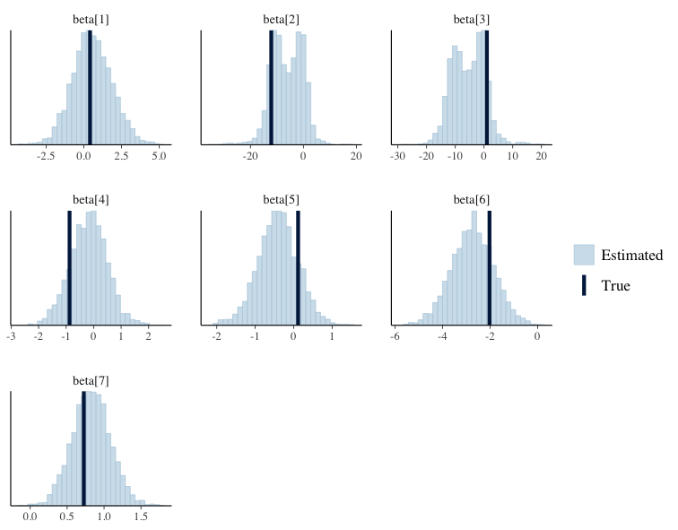

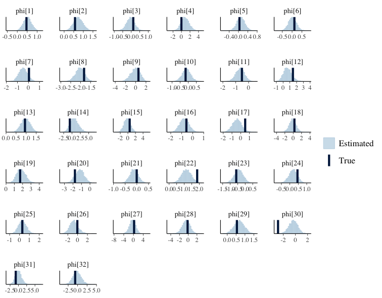

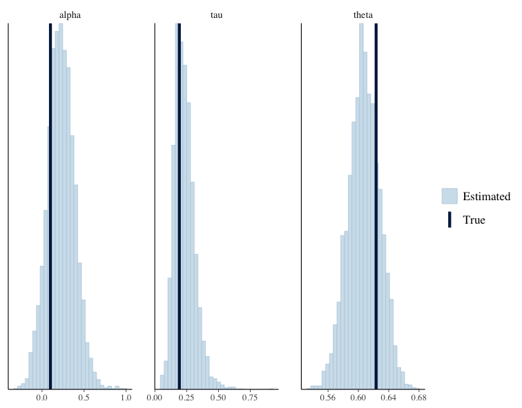

### Model result

1. Brief results

In the following is the basic model results :

```r
           mean se_mean   sd    2.5%     25%     50%     75%     98% n_eff Rhat
alpha     -2.67    0.00 0.04   -2.76   -2.70   -2.67   -2.64   -2.59   187  1.0
beta[1]   -0.53    0.03 0.38   -1.25   -0.80   -0.54   -0.29    0.25   143  1.0
beta[2]    0.19    0.23 2.11   -4.74   -1.01    0.26    1.40    4.38    86  1.1
beta[3]    0.33    0.22 2.09   -3.91   -0.84    0.26    1.48    5.04    94  1.0
beta[4]    0.32    0.03 0.25   -0.18    0.16    0.32    0.50    0.83    97  1.1
beta[5]   -0.34    0.02 0.20   -0.75   -0.48   -0.34   -0.21    0.06   109  1.1
beta[6]   -0.07    0.02 0.21   -0.52   -0.21   -0.06    0.08    0.32   134  1.0
beta[7]   -0.18    0.01 0.10   -0.36   -0.25   -0.18   -0.11    0.01   217  1.0
phi[1]    -0.09    0.00 0.08   -0.24   -0.14   -0.09   -0.04    0.05   852  1.0
phi[2]     0.03    0.00 0.08   -0.13   -0.02    0.03    0.08    0.19  2025  1.0
phi[3]    -0.23    0.00 0.09   -0.41   -0.29   -0.22   -0.16   -0.05  1803  1.0
phi[4]     0.14    0.00 0.12   -0.10    0.06    0.14    0.22    0.37  1829  1.0
phi[5]    -0.30    0.00 0.11   -0.52   -0.37   -0.30   -0.23   -0.09  3299  1.0
phi[6]    -0.06    0.00 0.10   -0.25   -0.12   -0.06    0.01    0.13  2359  1.0
phi[7]     0.09    0.00 0.10   -0.11    0.02    0.09    0.15    0.28  2368  1.0
phi[8]     0.09    0.00 0.10   -0.10    0.02    0.09    0.16    0.28  2423  1.0
phi[9]    -0.12    0.00 0.12   -0.35   -0.20   -0.12   -0.04    0.12  3345  1.0
phi[10]    0.07    0.00 0.11   -0.16   -0.01    0.07    0.14    0.28  2464  1.0
phi[11]   -0.10    0.00 0.12   -0.35   -0.19   -0.10   -0.02    0.13  4003  1.0
phi[12]    0.16    0.00 0.11   -0.06    0.08    0.16    0.23    0.36  2948  1.0
phi[13]   -0.45    0.00 0.15   -0.76   -0.55   -0.44   -0.34   -0.15  3698  1.0
phi[14]    0.09    0.00 0.13   -0.17    0.01    0.10    0.18    0.35  3833  1.0
phi[15]   -0.06    0.00 0.14   -0.34   -0.15   -0.06    0.03    0.20  3366  1.0
phi[16]    0.28    0.00 0.14    0.00    0.19    0.28    0.38    0.56  2951  1.0
phi[17]   -0.14    0.00 0.16   -0.46   -0.25   -0.14   -0.03    0.15  4033  1.0
phi[18]   -0.45    0.00 0.18   -0.80   -0.56   -0.45   -0.33   -0.12  1581  1.0
phi[19]    0.08    0.00 0.16   -0.24   -0.03    0.08    0.19    0.39  4147  1.0
phi[20]    0.40    0.00 0.16    0.10    0.29    0.40    0.51    0.70  1102  1.0
phi[21]   -0.08    0.00 0.17   -0.41   -0.20   -0.08    0.04    0.25  4140  1.0
phi[22]    0.04    0.00 0.18   -0.31   -0.08    0.04    0.16    0.37  4044  1.0
phi[23]    0.22    0.00 0.18   -0.13    0.10    0.22    0.34    0.56  2248  1.0
phi[24]    0.33    0.00 0.18   -0.03    0.21    0.33    0.45    0.69  3626  1.0
phi[25]    0.10    0.00 0.20   -0.30   -0.03    0.10    0.23    0.47  3735  1.0
phi[26]   -0.05    0.00 0.23   -0.53   -0.20   -0.05    0.11    0.38  3186  1.0
phi[27]    0.23    0.00 0.20   -0.16    0.10    0.23    0.37    0.63  2633  1.0
phi[28]    0.01    0.00 0.20   -0.39   -0.11    0.01    0.15    0.38  3371  1.0
phi[29]   -0.26    0.00 0.23   -0.73   -0.41   -0.25   -0.10    0.18  2812  1.0
phi[30]   -0.29    0.00 0.20   -0.70   -0.41   -0.28   -0.15    0.07  1902  1.0
phi[31]   -0.03    0.00 0.25   -0.55   -0.19   -0.02    0.14    0.44  3394  1.0
phi[32]    0.35    0.00 0.26   -0.16    0.18    0.35    0.53    0.86  3258  1.0
theta      0.01    0.00 0.01    0.00    0.00    0.01    0.01    0.03   213  1.0
tau        2.49    0.05 0.84    1.23    1.88    2.37    2.98    4.46   240  1.0
lp__    -812.85    0.20 4.82 -823.32 -815.77 -812.58 -809.53 -804.33   593  1.0
```

A quick check for the Rhat in our model is all very good. The posterior confidence interval of the parameters are show as the following plots.

2. Confidence intervial and interpretation

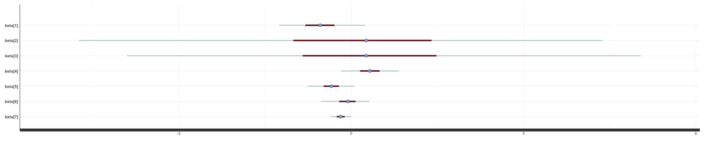

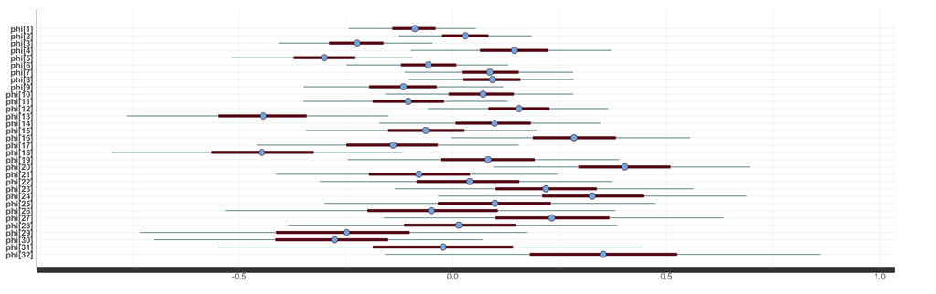

The state effects are obvious. We can see that $\phi_3$ (state 3), $\phi_5$ (state 5) , $\phi_{13}$ (state 13) and $\phi_{18}$ (state 18) have the nigative effect, which means these state is less likely to have default. However, $\phi_{20}$ (state 20) has a significantly postive effect.

[figure not shown]

As we can see, the overall offset effect is obvious that for about -2.67. And on avrage, there will have 1% of cities have no default at all. On 95% confidence interval, there will have less than 3% of cities have no default.

### Model Check

1. General Posterior Predict Check

In the plot below we have the kernel density estimate of the observed data (y, thicker curve) and 200 simulated data sets ($y_{rep}$, thin curves) from the posterior predictive distribution. If the model fits the data well, as it does here, there is little difference between the observed dataset and the simulated datasets.

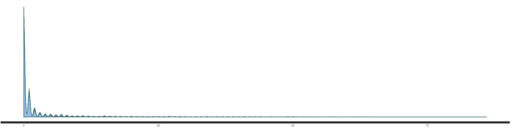

As we can see from the polt below, $y_{rep}$ behavior well in the four most common statistics. Ideally this vertical line would fall somewhere within the histogram, as what we did.

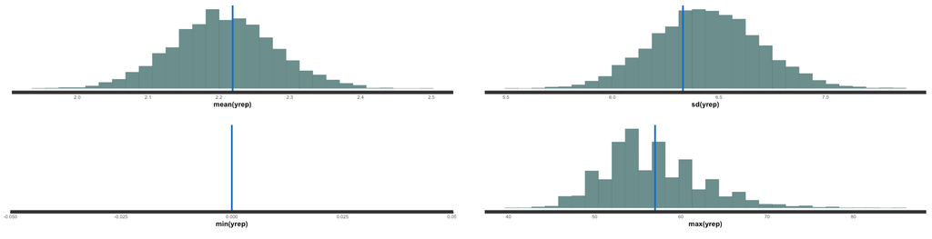

The plot below shows the observed and average simulated value. As we can see the model fit the data very well without obvious outliers.

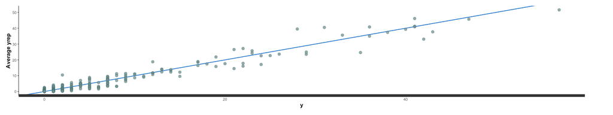

The residuals centered at 0 and have small variance. This indecates that the model fit is acceptable.

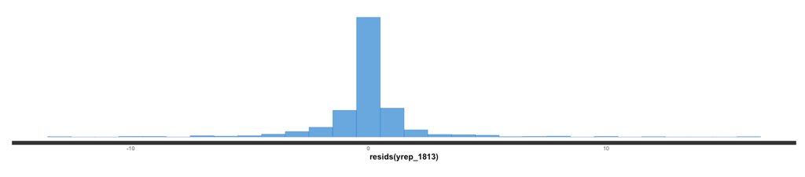

2. Cross Validation

In order to determine our model performance, again we do the 5-floder cross validation. And we calculate the MSE for each training dataset with our model. And then we get the average MSE. The stan code we used to simulate the $y_hat$ is as the following:

```r
generated quantities{
  int y_rep_cv[N_test];
  real<lower =0,upper=1> zero_test[N_test];
  for (i in 1:N_test){
    zero_test[i] = uniform_rng(0,1);
    if (zero_test[i] < theta){
      y_rep_cv[i] = 0;
      }
    else{
      y_rep_cv[i] = binomial_rng(n_city_test[i],
                    inv_logit( alpha[state_test[i]] +
                    X_test[i,]* beta));
      }
  }
}
```

Acrroding to the result, the baseline MSE is 128164. But for our model, the average MSE is **7583** with the standard deviation **6831**. Thus, we can say that our model have a huge improve from the baseline.

# Discussion: Individual level Analysis

## Failure of Logistic Regression

In this section, we will analysis the dataset for individual level. The model we will use For individual level, it’s more resonable to use the logistic regression instead of the binormial regression.
$$p(y_i) =\begin{cases}
1, & defaule \space at \space least \space once \\
0, & otherwise \end{cases}$$
However, the CAR still can be used.Thus, the new model for individual level can be summarized as these:
$$y_{ij} \sim bernoulli(logit^{-1}(a + \phi_j + x_{ij}\beta))$$
As the same the zero-inflated model extension will also be applied in the individual level.
$$p(y_i | \theta,a,\beta) =\begin{cases}
\theta + (1-\theta) \times bernoulli(0 |a,\beta,\phi ) & y_i =0 \\
(1-\theta) \times bernoulli(0 |a,\beta,\phi ) & y_i > 0 \end{cases}$$

The model result is in the following:

```r
            mean se_mean    sd       1% n_eff Rhat
alpha      -0.82    0.18  1.09    -2.64    36 1.11
beta[1]    -0.13    0.02  0.18    -0.56   100 1.04
beta[2]     0.08    0.04  0.25    -0.26    32 1.13
beta[3]     0.03    0.06  0.27    -1.08    23 1.14
beta[4]     0.01    0.03  0.15    -0.29    27 1.14
beta[5]    -0.08    0.05  0.27    -0.67    30 1.13
beta[6]    -0.27    0.04  0.23    -1.03    30 1.13
beta[7]    -0.02    0.00  0.06    -0.22   154 1.01
phi[1]     -0.11    0.01  0.29    -0.85  3132 1.00
phi[2]      0.16    0.00  0.25    -0.45  3095 1.00
phi[3]     -0.14    0.01  0.14    -0.60   101 1.04
phi[4]      0.27    0.01  0.34    -0.43   543 1.01
phi[5]      0.02    0.00  0.24    -0.58  3944 1.00
phi[6]      0.36    0.03  0.30    -0.10   110 1.03
phi[7]      0.04    0.00  0.15    -0.30  3151 1.00
phi[8]     -0.41    0.03  0.22    -1.18    43 1.09
phi[9]     -0.15    0.01  0.22    -0.82   637 1.01
phi[10]    -0.69    0.04  0.34    -1.82    81 1.05
phi[11]     0.17    0.00  0.18    -0.21  1320 1.01
phi[12]     0.15    0.01  0.20    -0.25   537 1.01
phi[13]     0.82    0.04  0.36     0.24    84 1.05
phi[14]     0.55    0.03  0.38    -0.10   123 1.04
phi[15]     0.19    0.01  0.17    -0.16   655 1.01
phi[16]    -0.48    0.03  0.24    -1.25    53 1.07
phi[17]    -0.41    0.02  0.25    -1.23   117 1.03
phi[18]    -0.11    0.01  0.16    -0.59   664 1.01
phi[19]    -0.20    0.01  0.24    -0.91   682 1.01
phi[20]     0.47    0.04  0.36    -0.08    89 1.04
phi[21]    -0.17    0.01  0.21    -0.82   466 1.01
phi[22]    -0.13    0.00  0.22    -0.73  2394 1.00
phi[23]     0.07    0.00  0.21    -0.45  3670 1.00
phi[24]    -0.03    0.01  0.33    -0.79  3470 1.00
phi[25]     0.07    0.01  0.29    -0.59  1547 1.01
phi[26]     0.23    0.02  0.28    -0.26   163 1.03
phi[27]     0.65    0.03  0.38     0.04   135 1.03
phi[28]    -0.74    0.04  0.48    -2.24   180 1.03
phi[29]     0.10    0.01  0.33    -0.71  3152 1.00
phi[30]    -0.35    0.01  0.31    -1.24   762 1.01
phi[31]    -0.15    0.01  0.34    -1.05  2137 1.00
phi[32]    -0.02    0.01  0.37    -0.99  3879 1.00
theta       0.69    0.03  0.23     0.05    64 1.06
lp__    -7215.11    2.34 13.51 -7251.54    33 1.11
```

# Conclusion

# References

- Besag, Julian, Jeremy York, and Annie Mollié. (1991) Bayesian image restoration, with two applications in spatial statistics. *Annals of the institute of statistical mathematics*, 43.1: 1-20.
- Gelfand, Alan E., and Penelope Vounatsou. (2003) Proper multivariate conditional autoregressive models for spatial data analysis. *Biostatistics* 4.1: 11-15.
- Jin, Xiaoping, Bradley P. Carlin, and Sudipto Banerjee. (2005) Generalized hierarchical multivariate CAR models for areal data. *Biometrics* 61.4: 950-961.
- Bob Carpenter. (2018) [Predator-Prey Population Dynamics: the Lotka-Volterra model in Stan](http://mc-stan.org/users/documentation/case-studies/lotka-volterra-predator-prey.html#data-lynx-and-hare-pelts-in-canada). *Rstan Document For Example*.
- Max Joseph. (2011) [Exact sparse CAR models in Stan](http://mc-stan.org/users/documentation/case-studies/mbjoseph-CARStan.html). *Rstan Document For Example*.
- Stan Development Team (2017) *Stan Modeling Language Users Guide and Reference Manual*, Version 2.17, http://mc-stan.org.
- Vehtari, A., Gelman, A. & Gabry, J. (2017) Practical Bayesian model evaluation using leave-one-out cross-validation and WAIC. *Journal of Statistics and Computing* 27(5):1413–1432.
- Andrew Gelman, John B. Carlin, Hal S. Stern, David B. Dunson, Aki Vehtari, Donald B. Rubin (2014) [*Bayesian Data Analysis*](https://www.google.com/search?q=bayesian+data+analysis&oq=bayesian+data+analysis&aqs=chrome.0.69i59j69i60l2j69i61j69i65j0.3253j1j4&sourceid=chrome&ie=UTF-8)
- Stan Development Team (2018) [*Bayesian Statistics Using Stan*](http://www.stat.columbia.edu/~gelman/bda.course/_book/)

# Statements

## Source code

All of the source code, data, text, and images for this case study are available on GitHub at： [A bayesian approach to indentify morgage default rate at city level](https://github.com/ChrisChen0429/BDA_project)

## Complete Stan program

The complete Stn program for this case study are available on the google at: [A bayesian approach to indentify morgage default rate at city level](https://docs.google.com/document/d/1N0XtUlnsnYi_bInkrbTQG2DCD1Hf7mXaSoZWQbWrOqg/edit?usp=sharing)

# Acknowledgements

# Licenses

Code © 2017–2018, Columbia University in New York, licensed under BSD-3.

Text © Andres Potapczynski, Jongwoo Choi, Yi Chen